# Titanic Data Clean

Parece haber un efecto de interacción entre la edad y el sexo. Hubo más sobrevivientes de hombres que adultos varones, que fueron mayores que los varones. Por el contrario, hubo más sobrevivientes de niñas que mujeres de la tercera edad, que fueron mayores que las mujeres adultas. En general, hubo más mujeres supervivientes en comparación con los hombres en todos los grupos de edad.

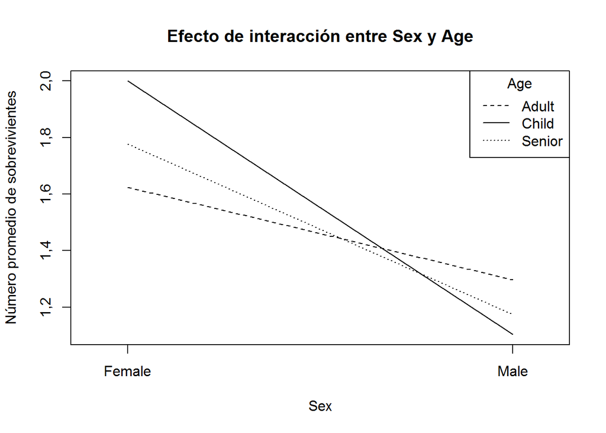

```r
interaction.plot(df$Sex, df$Age, df$Survived, xlab="Sex", ylab="Número promedio de sobrevivientes",
                 main="Efecto de interacción entre Sex y Age", legend=FALSE, xtick=FALSE, xaxt="n")
axis(1, c(1,2), labels=c("Female", "Male"))
legend("topright", c("Adult","Child", "Senior"), lty=c("dashed", "solid", "dotted"), title="Age")
```

No parece haber ningún efecto de interacción entre Sexo y Puerto de Embarque.

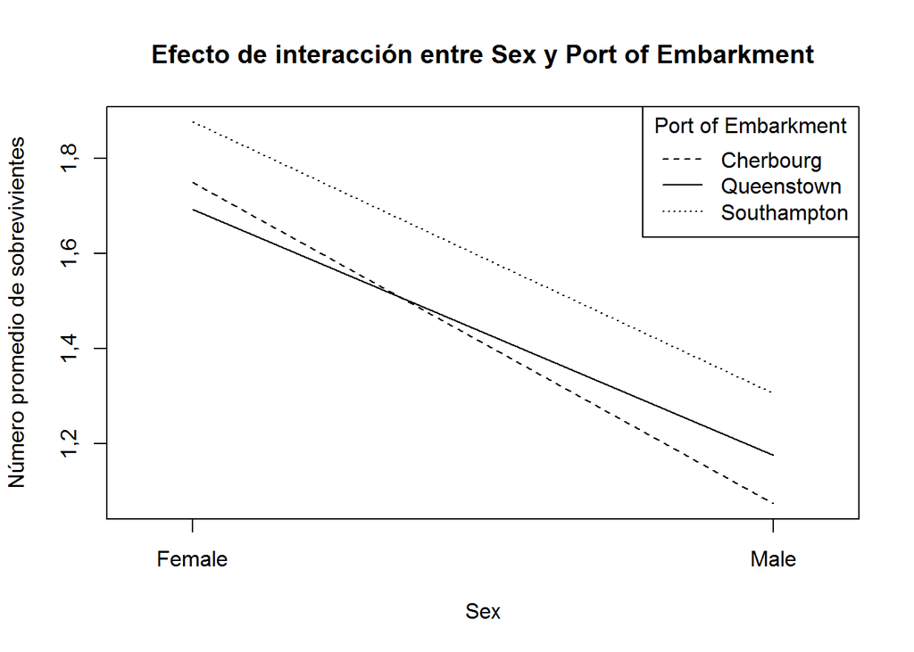

```r
interaction.plot(df$Sex, df$Embarked, df$Survived, xlab="Sex", ylab="Número promedio de sobrevivientes",
                 main="Efecto de interacción entre Sex y Port of Embarkment", legend=FALSE, xtick = FALSE, xaxt="n")
axis(1, c(1,2), labels=c("Female", "Male"))
legend("topright", c("Cherbourg","Queenstown","Southampton"), lty=c("dashed", "solid", "dotted"),
       title="Port of Embarkment")
```

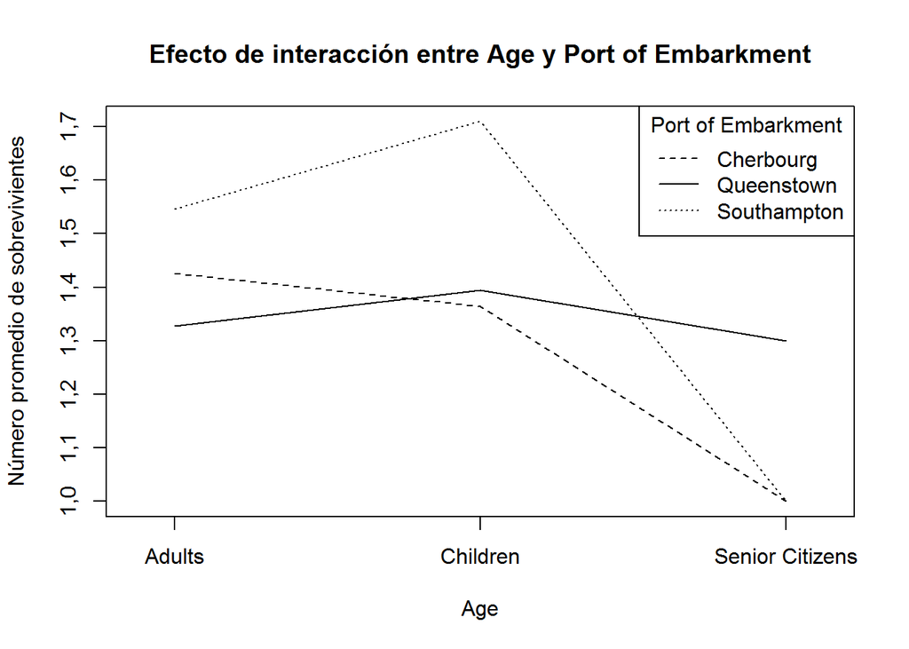

```r
interaction.plot(df$Age, df$Embarked, df$Survived, xlab="Age", ylab="Número promedio de sobrevivientes",
                 main="Efecto de interacción entre Age y Port of Embarkment", legend=FALSE, xtick = FALSE, xaxt="n")
axis(1, c(1,2,3), labels=c("Adults", "Children", "Senior Citizens"))
legend("topright", c("Cherbourg","Queenstown","Southampton"), lty=c("dashed", "solid", "dotted"),
       title="Port of Embarkment")
```

## 4.3 ANOVA

Los principales efectos de Clase de Pasajero, Sexo y Puerto de Embarque son significativos. Hubo más sobrevivientes en la primera clase en comparación con la segunda y tercera clase. Hubo más mujeres sobrevivientes. No hay un efecto significativo de la edad, lo que significa que el número medio de supervivientes de todos los grupos de edad fue casi el mismo.

```r
me1 = aov(df$Survived ~ df$Pclass)
anova(me1)
```

```
## Analysis of Variance Table
##
## Response: df$Survived
##            Df  Sum Sq Mean Sq F value    Pr(>F)
## df$Pclass   1  24,143 24,1429  115,03 < 2,2e-16 ***
## Residuals 889 186,584  0,2099
## ---
## Signif. codes:  0 '***' 0,001 '**' 0,01 '*' 0,05 '.' 0,1 ' ' 1
```

```r
me2 = aov(df$Survived ~ df$Sex)
anova(me2)
```

```
## Analysis of Variance Table
##
## Response: df$Survived
##            Df  Sum Sq Mean Sq F value    Pr(>F)
## df$Sex      1  62,213  62,213  372,41 < 2,2e-16 ***
## Residuals 889 148,514   0,167
## ---
## Signif. codes:  0 '***' 0,001 '**' 0,01 '*' 0,05 '.' 0,1 ' ' 1
```

```r
me3 = aov(df$Survived ~ df$Age)
anova(me3)
```

```
## Analysis of Variance Table
##
## Response: df$Survived
##            Df  Sum Sq  Mean Sq F value Pr(>F)
## df$Age      1   0,008 0,008009  0,0338 0,8542
## Residuals 889 210,719 0,237030
```

```r
me4 = aov(df$Survived ~ df$Embarked)
anova(me4)
```

```
## Analysis of Variance Table
##
## Response: df$Survived
##              Df  Sum Sq Mean Sq F value    Pr(>F)
## df$Embarked   1   5,925  5,9246  25,717 4,811e-07 ***
## Residuals   889 204,803  0,2304
## ---
## Signif. codes:  0 '***' 0,001 '**' 0,01 '*' 0,05 '.' 0,1 ' ' 1
```

```r
ie12 = aov(df$Survived ~ df$Pclass * df$Sex)
anova(ie12)
```

```
## Analysis of Variance Table
##
## Response: df$Survived
##                   Df  Sum Sq Mean Sq F value    Pr(>F)
## df$Pclass          1  24,143  24,143 164,061 < 2,2e-16 ***
## df$Sex             1  53,337  53,337 362,450 < 2,2e-16 ***
## df$Pclass:df$Sex   1   2,718   2,718  18,471 1,916e-05 ***
## Residuals        887 130,529   0,147
## ---
## Signif. codes:  0 '***' 0,001 '**' 0,01 '*' 0,05 '.' 0,1 ' ' 1
```

```r
ie13 = aov(df$Survived ~ df$Pclass * df$Age)
anova(ie13)
```

```
## Analysis of Variance Table
##
## Response: df$Survived
##                   Df  Sum Sq Mean Sq  F value    Pr(>F)
## df$Pclass          1  24,143 24,1429 115,9770 < 2,2e-16 ***
## df$Age             1   0,000  0,0000   0,0001  0,991713
## df$Pclass:df$Age   1   1,938  1,9378   9,3088  0,002348 **
## Residuals        887 184,647  0,2082
## ---
## Signif. codes:  0 '***' 0,001 '**' 0,01 '*' 0,05 '.' 0,1 ' ' 1
```

```r
ie14 = aov(df$Survived ~ df$Pclass * df$Embarked)
anova(ie14)
```

```
## Analysis of Variance Table
##
## Response: df$Survived
##                        Df  Sum Sq Mean Sq F value    Pr(>F)
## df$Pclass               1  24,143 24,1429 116,817 < 2,2e-16 ***
## df$Embarked             1   2,754  2,7540  13,325 0,0002771 ***
## df$Pclass:df$Embarked   1   0,512  0,5115   2,475 0,1160273
## Residuals             887 183,319  0,2067
## ---
## Signif. codes:  0 '***' 0,001 '**' 0,01 '*' 0,05 '.' 0,1 ' ' 1
```

```r
ie23 = aov(df$Survived ~ df$Sex * df$Age)
anova(ie23)
```

```
## Analysis of Variance Table
##
## Response: df$Survived
##                Df  Sum Sq Mean Sq  F value  Pr(>F)
## df$Sex          1  62,213  62,213 373,9967 < 2e-16 ***
## df$Age          1   0,050   0,050   0,3019 0,58284
## df$Sex:df$Age   1   0,914   0,914   5,4960 0,01928 *
## Residuals     887 147,550   0,166
## ---
## Signif. codes:  0 '***' 0,001 '**' 0,01 '*' 0,05 '.' 0,1 ' ' 1
```

```r
ie24 = aov(df$Survived ~ df$Sex * df$Embarked)
anova(ie24)
```

```
## Analysis of Variance Table
##
## Response: df$Survived
##                     Df  Sum Sq Mean Sq  F value    Pr(>F)
## df$Sex               1  62,213  62,213 378,4640 < 2,2e-16 ***
## df$Embarked          1   2,526   2,526  15,3691 9,524e-05 ***
## df$Sex:df$Embarked   1   0,180   0,180   1,0932    0,2961
## Residuals          887 145,808   0,164
## ---
## Signif. codes:  0 '***' 0,001 '**' 0,01 '*' 0,05 '.' 0,1 ' ' 1
```

```r
ie34 = aov(df$Survived ~ df$Age * df$Embarked)
anova(ie34)
```

```
## Analysis of Variance Table
##
## Response: df$Survived
##                     Df  Sum Sq Mean Sq F value    Pr(>F)
## df$Age               1   0,008  0,0080  0,0348    0,8521
## df$Embarked          1   5,935  5,9348 25,7725 4,681e-07 ***
## df$Age:df$Embarked   1   0,529  0,5294  2,2990    0,1298
## Residuals          887 204,255  0,2303
## ---
## Signif. codes:  0 '***' 0,001 '**' 0,01 '*' 0,05 '.' 0,1 ' ' 1
```

### 4.3.2 Diagnóstico y verificación de adecuación del modelo

El diagrama Q-Q es una herramienta para comparar dos distribuciones entre sí en base a la comparación de sus cuantiles. Ninguno de los gráficos de Q-Q a continuación se adhieren a la línea, lo que significa que los datos son de naturaleza altamente no lineal. Además, la no linealidad de los puntos sugiere que los datos no se distribuyen normalmente.

El gráfico residual se utiliza en el análisis de datos estadísticos para detectar la no linealidad de los datos, varianzas de errores desiguales y valores atípicos. En la mayoría de las siguientes parcelas residuales vs fit, los residuos no rebotan aleatoriamente alrededor de la línea cero, pero parecen ajustarse a una línea que tiene una pendiente negativa. Esto sugiere que los datos no son de naturaleza lineal. Los residuos forman aproximadamente una banda horizontal alrededor de la línea cero, lo que sugiere que las varianzas de los términos de error son iguales. Por último, no hay residuos que se destaquen del patrón básico de los residuos, lo que sugiere que no hay valores atípicos.

Estas observaciones sugieren que el conjunto de datos no ha cumplido todas las suposiciones para implementar ANOVA. Y esto es cierto porque, como se explicó anteriormente, no hubo alcance de replicación y medidas repetidas. Sin embargo, aún obtenemos resultados razonables porque hubo algunas suposiciones para ANOVA que eran verdaderas en el conjunto de datos.

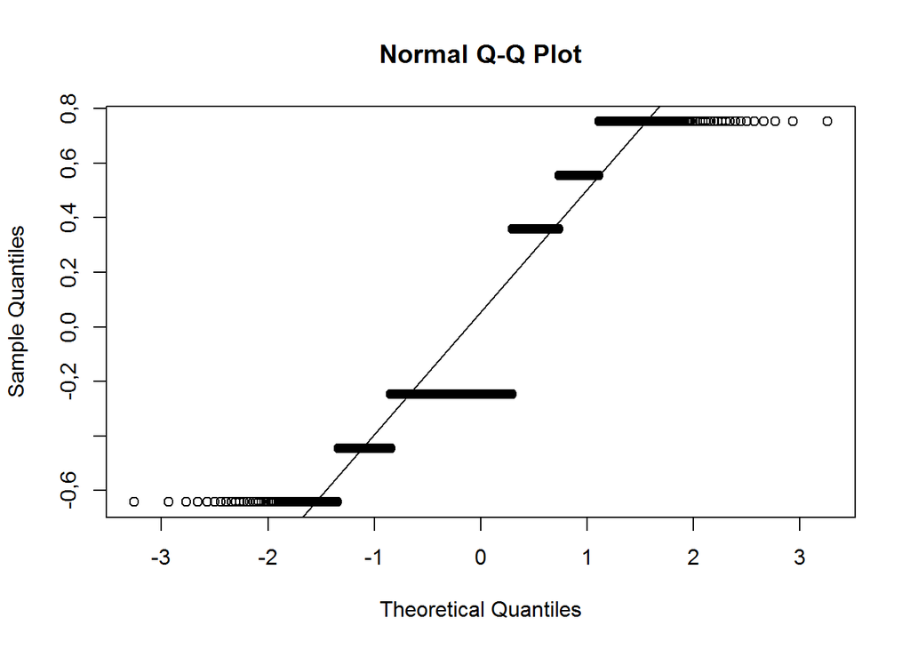

```r
qqnorm(residuals(me1))
qqline(residuals(me1))
```

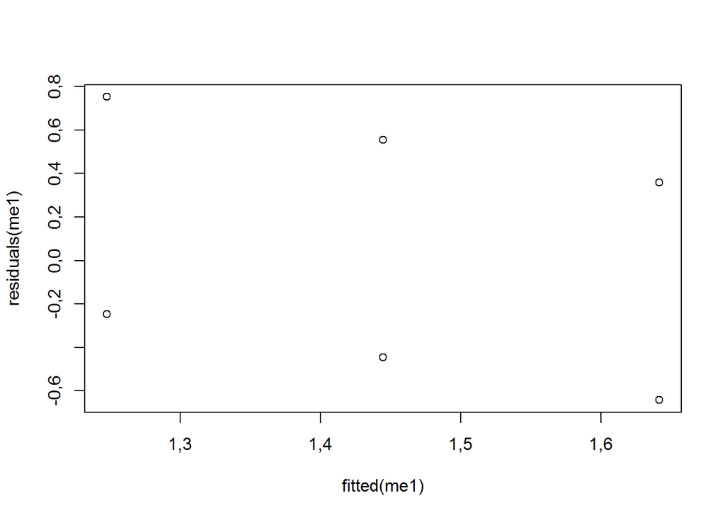

```r
plot(fitted(me1), residuals(me1))
```

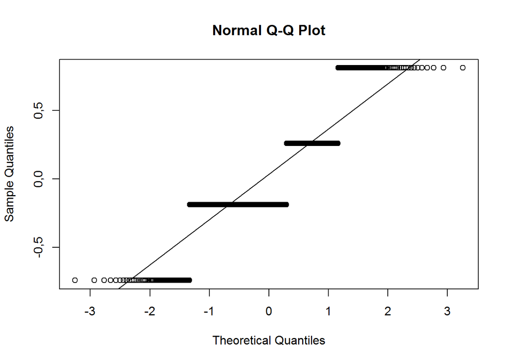

```r
qqnorm(residuals(me2))
qqline(residuals(me2))
```

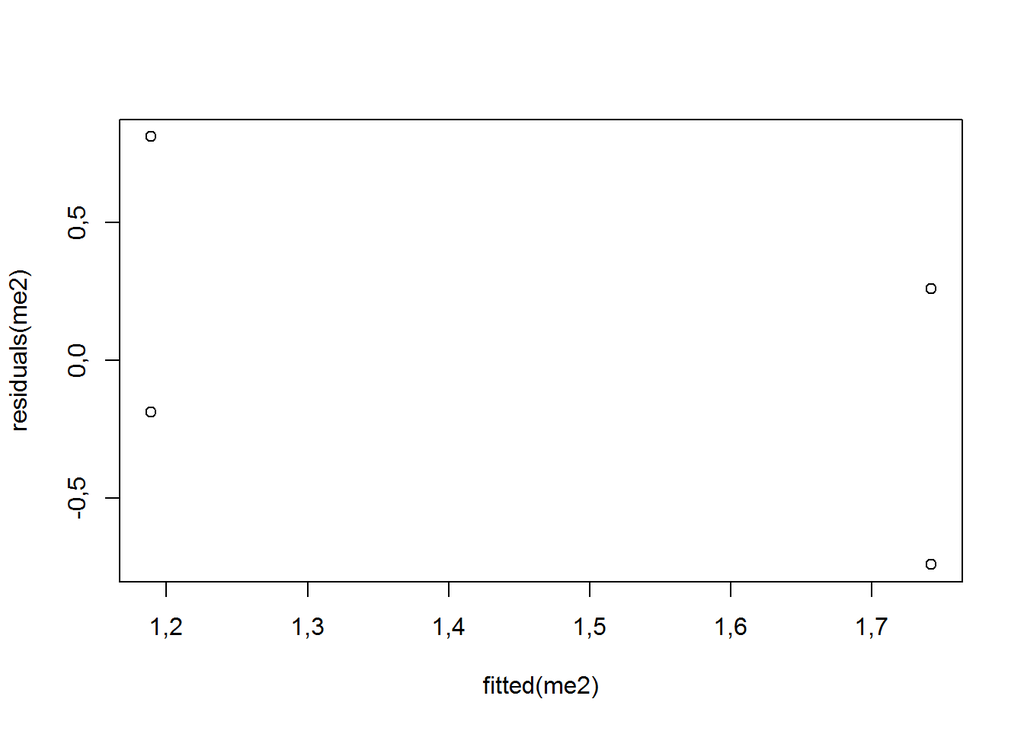

```r
plot(fitted(me2), residuals(me2))
```

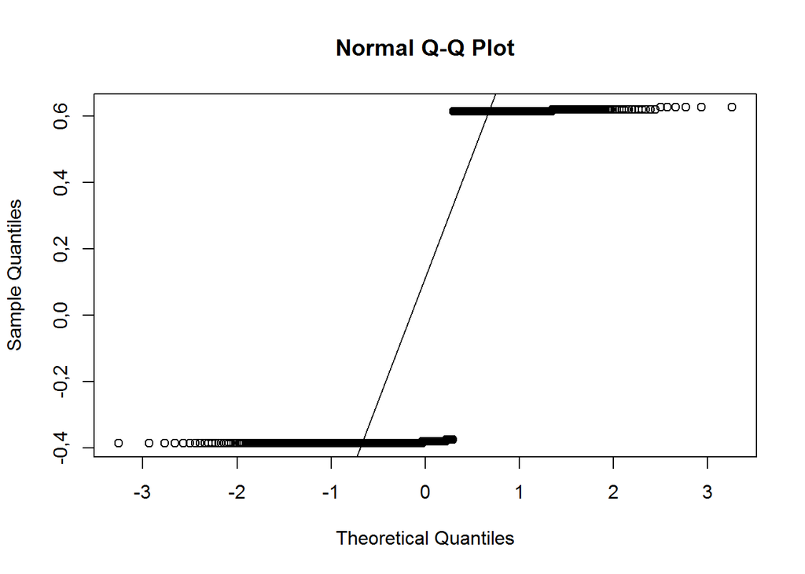

```r
qqnorm(residuals(me3))
qqline(residuals(me3))
```

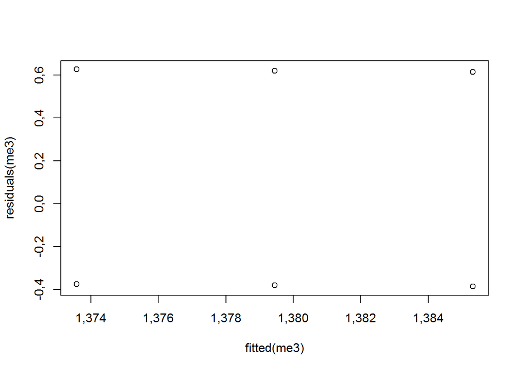

```r
plot(fitted(me3), residuals(me3))
```

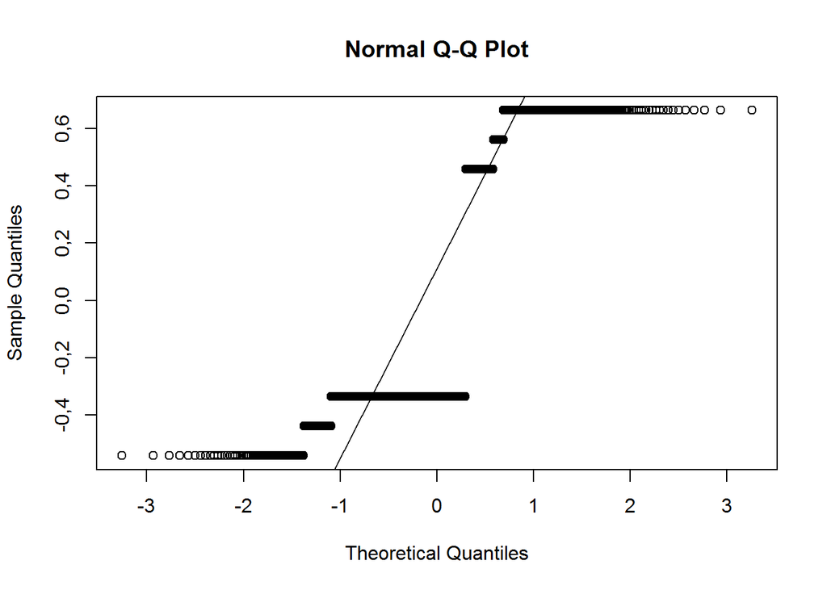

```r
qqnorm(residuals(me4))
qqline(residuals(me4))
```

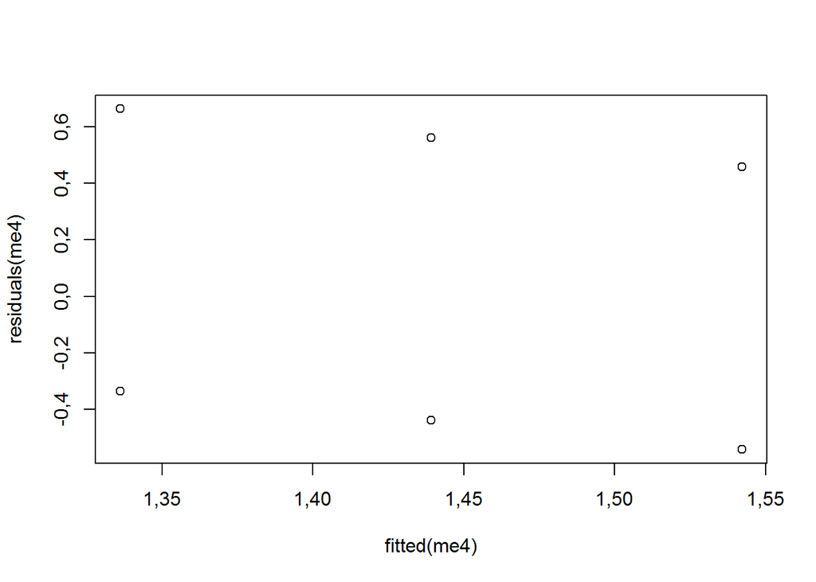

```r
plot(fitted(me4), residuals(me4))
```

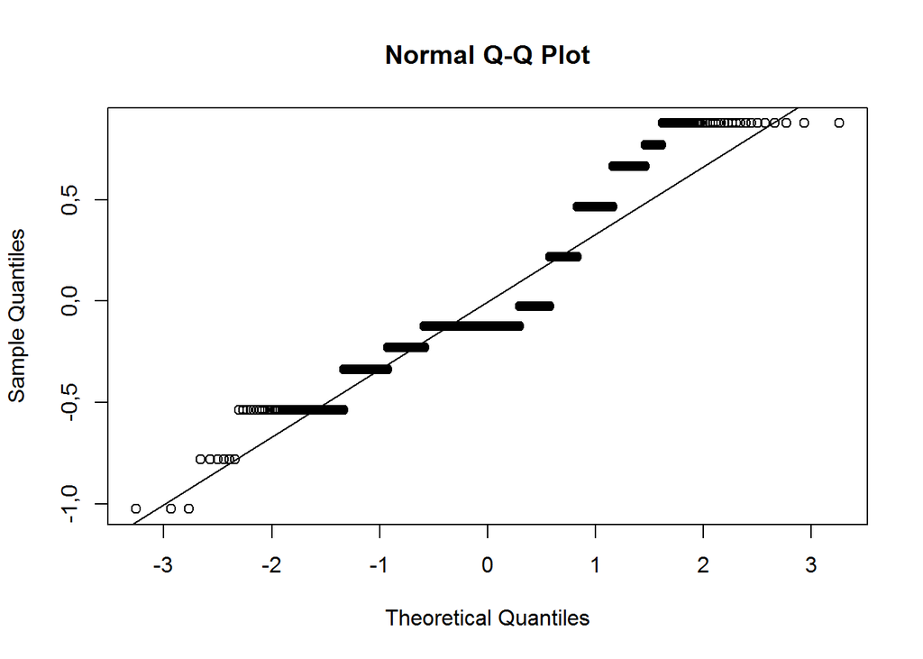

```r
qqnorm(residuals(ie12))
qqline(residuals(ie12))
```

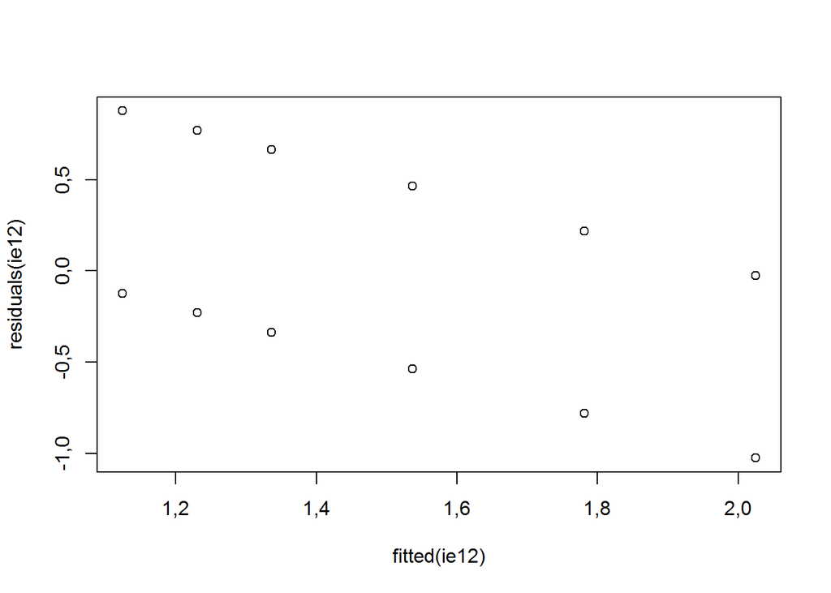

```r
plot(fitted(ie12), residuals(ie12))
```

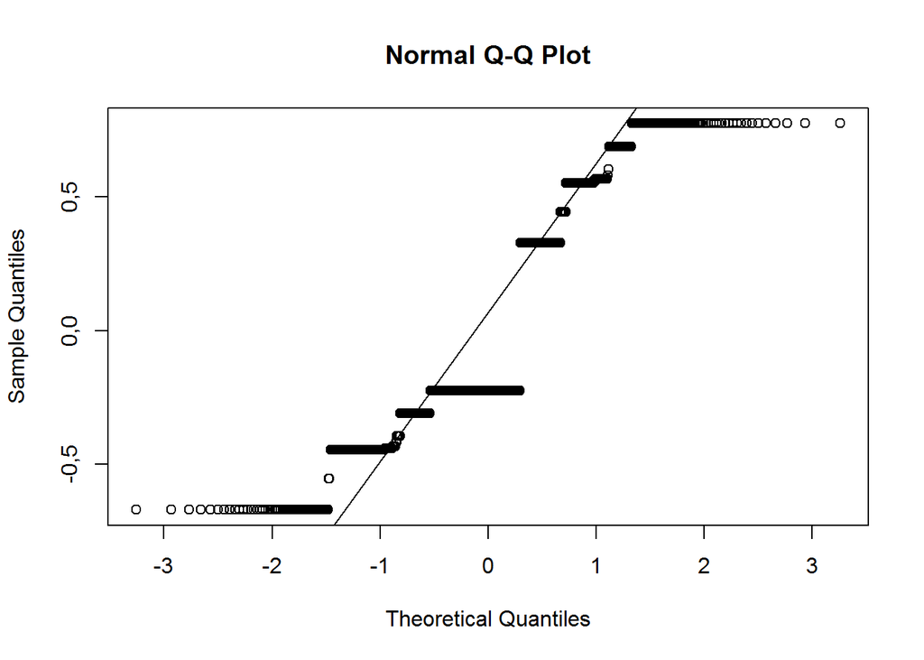

```r
qqnorm(residuals(ie13))
qqline(residuals(ie13))
```

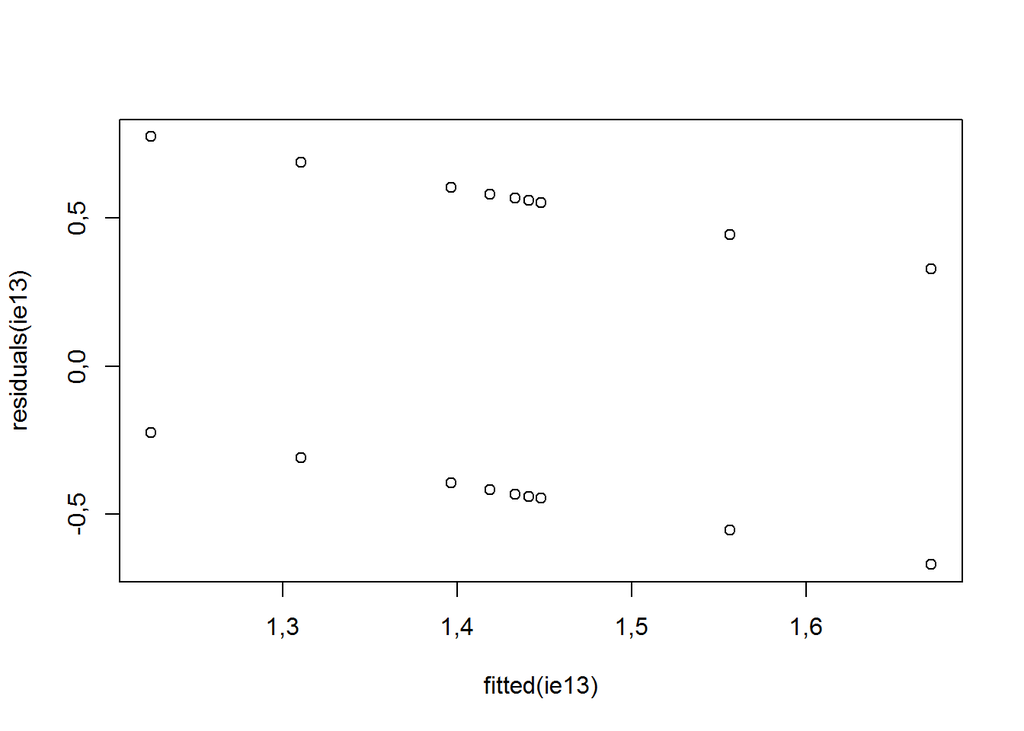

```r
plot(fitted(ie13), residuals(ie13))
```

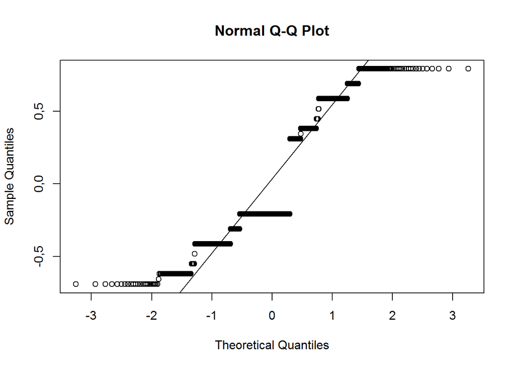

```r
qqnorm(residuals(ie14))
qqline(residuals(ie14))
```

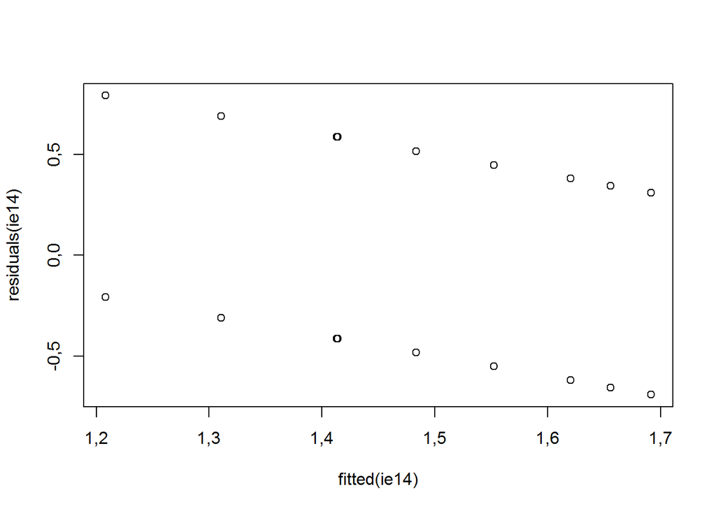

```r
plot(fitted(ie14), residuals(ie14))
```

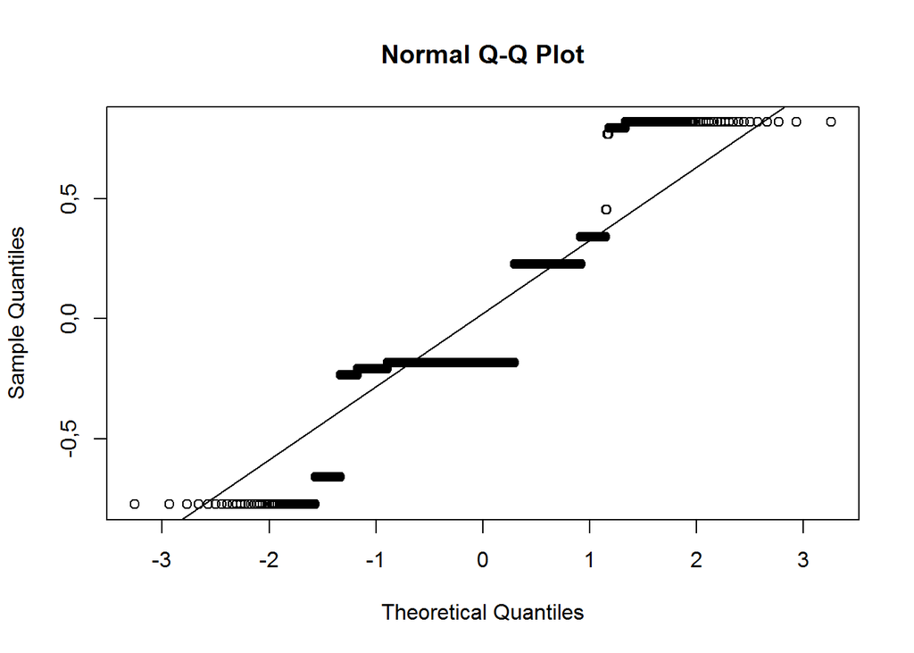

```r
qqnorm(residuals(ie23))
qqline(residuals(ie23))
```

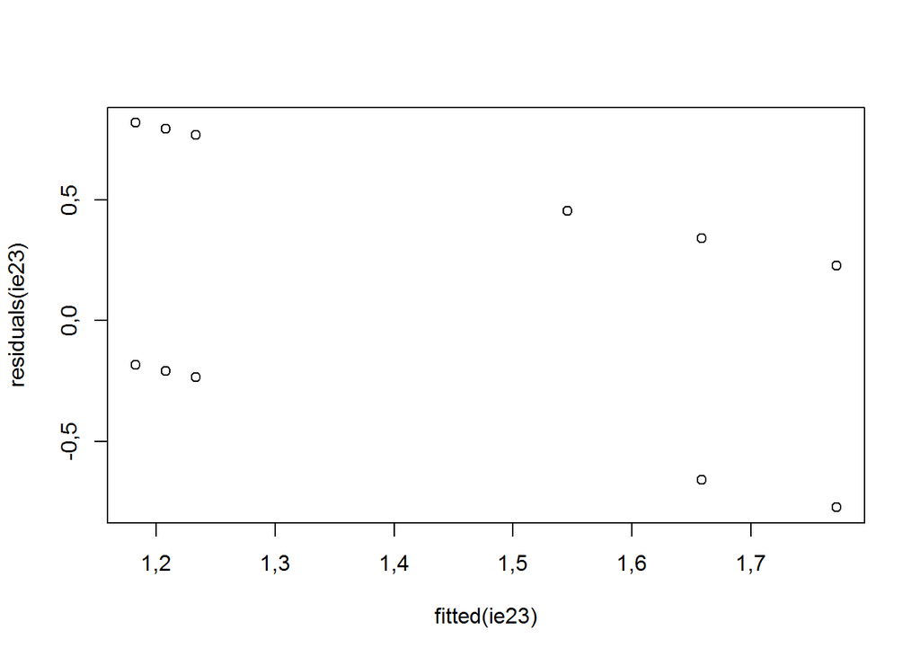

```r
plot(fitted(ie23), residuals(ie23))
```

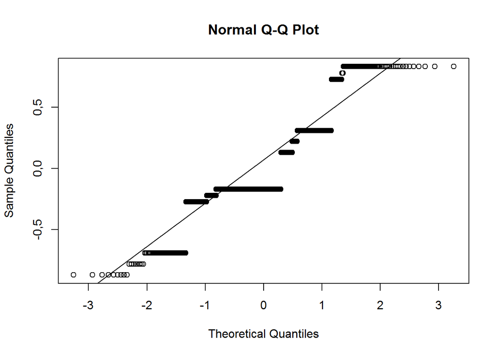

```r
qqnorm(residuals(ie24))
qqline(residuals(ie24))
```

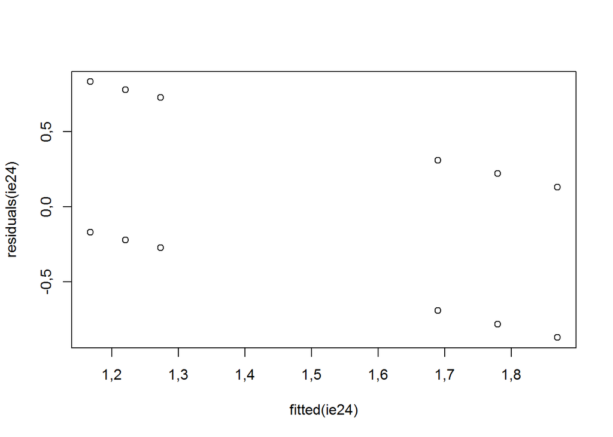

```r
plot(fitted(ie24), residuals(ie24))
```

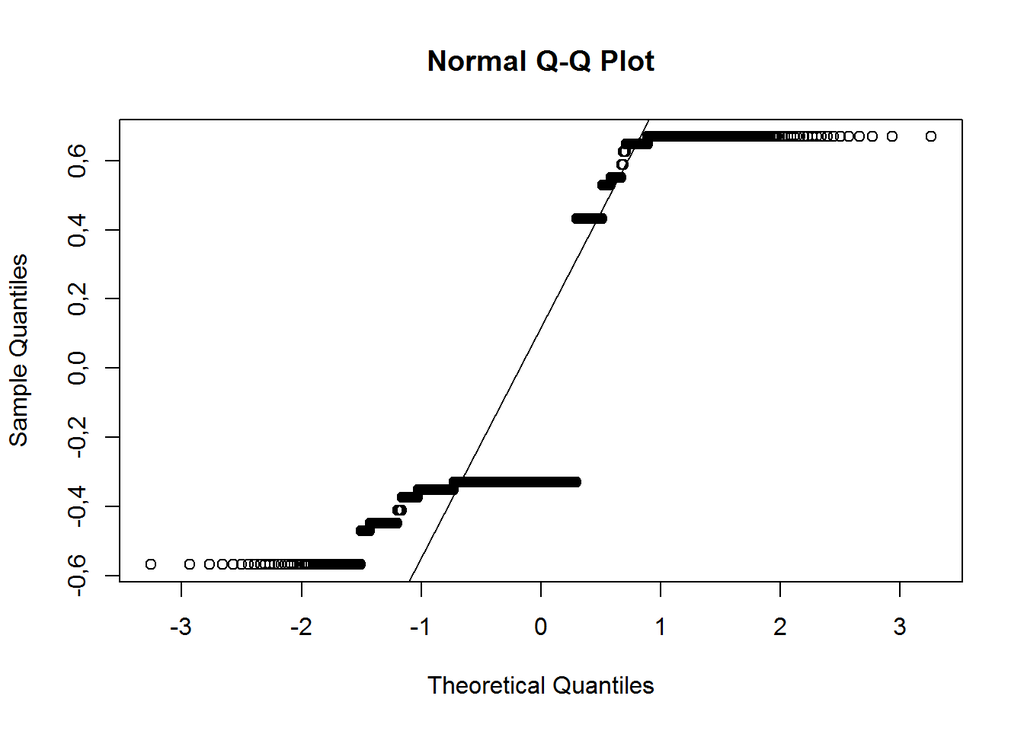

```r
qqnorm(residuals(ie34))
qqline(residuals(ie34))
```

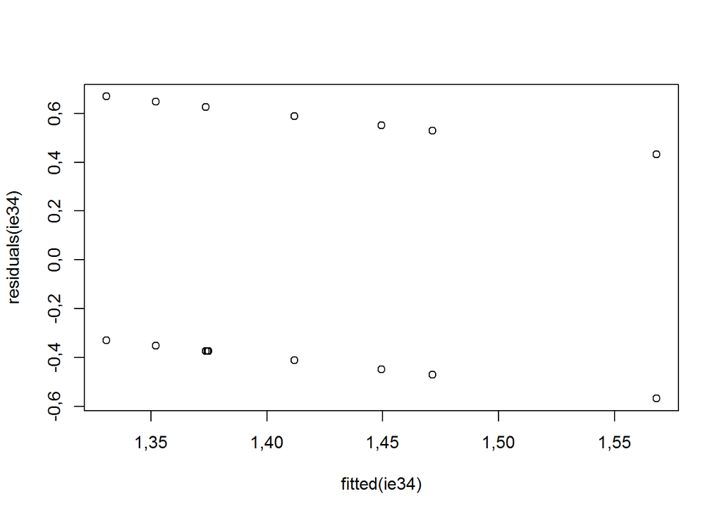

```r
plot(fitted(ie34), residuals(ie34))
```

## 4.4 Evaluación de algoritmos

Intentaremos algunos algoritmos lineales y no lineales: * Algoritmos Lineales: Regresión Logística (LG), Análisis Lineal Discriminado (LDA) y Regresión Logística Regularizada (GLMNET). * Algoritmos no lineales: k-Nearest Neighbors (KNN), árboles de clasificación y regresión (CART), Naive Bayes (NB) y máquinas de vectores de soporte con funciones de base radial (SVM).

### 4.4.1 Selección y verificación de variables

A partir de los valores de muestra que se muestran en el conjunto de datos, podemos ver que PassengerId, Name, Ticket, Cabin y Embarked probablemente no serán útiles en nuestro análisis, por lo que decidimos que podemos eliminar estas variables.

```r
# se eliminan variables redundantes
datasetTrain <- titanic_train[,c(-3, -8, -10, -11, -c(12:23))]

datasetTrain$Pclass = as.integer(datasetTrain$Pclass)
datasetTrain$Age = as.integer(datasetTrain$Age)
#datasetTrain$Survived = as.integer(datasetTrain$Survived)
# sumario
summary(datasetTrain)
```

```
##  Survived     Pclass          Sex           Age            SibSp
##  0:549    Min.   :1,000   female:314   Min.   : 0,00   Min.   :0,000
##  1:342    1st Qu.:2,000   male  :577   1st Qu.:21,00   1st Qu.:0,000
##           Median :3,000                Median :28,00   Median :0,000
##           Mean   :2,309                Mean   :29,95   Mean   :0,523
##           3rd Qu.:3,000                3rd Qu.:38,00   3rd Qu.:1,000
##           Max.   :3,000                Max.   :80,00   Max.   :8,000
##      Parch             Fare
##  Min.   :0,0000   Min.   :  0,00
##  1st Qu.:0,0000   1st Qu.:  7,91
##  Median :0,0000   Median : 14,45
##  Mean   :0,3816   Mean   : 32,20
##  3rd Qu.:0,0000   3rd Qu.: 31,00
##  Max.   :6,0000   Max.   :512,33
```

```r
sapply(datasetTrain, class)
```

```
##  Survived    Pclass       Sex       Age     SibSp     Parch      Fare
##  "factor" "integer"  "factor" "integer" "integer" "integer" "numeric"
```

Echemos un vistazo más de cerca a las distribuciones de clase.

```r
# distribución de clases
cbind(freq=table(datasetTrain$Survived), percentage=prop.table(table(datasetTrain$Survived))*100)
```

```
##   freq percentage
## 0  549   61,61616
## 1  342   38,38384
```

Hay algún desequilibrio en los valores de la clase. Observamos una división aproximada de 60% a 40% para Died (= 0) y Survived (= 1) en los valores de clase.

```r
datasetTrain[,3] <- as.numeric((datasetTrain[,3]))
complete_cases <- complete.cases(datasetTrain)

kable(cor(datasetTrain[complete_cases,2:5]), caption = "Correlación del conjunto de datos",digits = 3, padding = 2, align = 'r')
```

Correlación del conjunto de datos

|  | Pclass | Sex | Age | SibSp |
| --- | --- | --- | --- | --- |
| Pclass | 1,000 | 0,132 | -0,357 | 0,083 |
| Sex | 0,132 | 1,000 | 0,104 | -0,115 |
| Age | -0,357 | 0,104 | 1,000 | -0,275 |
| SibSp | 0,083 | -0,115 | -0,275 | 1,000 |

```r
#cor(datasetTrain[complete_cases,2:5])
```

Los valores por encima de 0,75 o por debajo de -0,75 son indicativos de una correlación alta positiva o alta negativa. A partir de los resultados anteriores, las variables no están altamente correlacionadas en este conjunto de datos.

### 4.4.2 Visualizacion del conjunto de datos

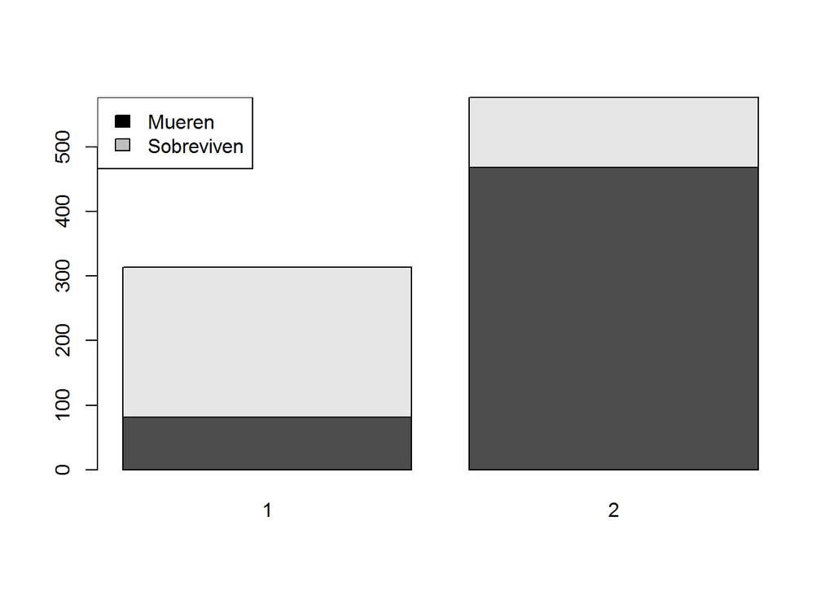

```r
# barra de hombres y mujeres que sobrevivieron
barplot(table(datasetTrain$Survived, datasetTrain[,3]))
legend("topleft", legend = c("Mueren", "Sobreviven"), fill=c("black","grey"))
```

### 4.4.3 Opciones de prueba y métrica de evaluación.

Vamos a definir un test de control. Usaremos una validación cruzada de 10 veces con 3 repeticiones. Esta es una buena configuración de test de control estándar. Es un problema de clasificación binario. Para simplificar, utilizaremos métricas de precisión y Kappa.

[output not shown]

```r
# 10-fold validación cruzada con 3 repeticiones
trainControl <- trainControl(method="repeatedcv", number=10, repeats=3)
metric <- "Accuracy"
```

### 4.4.4 Algoritmos de muestreo (Spot-Check Algorithms)

```r
# LG
set.seed(7)
fit.glm <- train(Survived~., data=datasetTrain, method="glm", metric=metric,
                 trControl=trainControl)

# LDA
set.seed(7)
fit.lda <- train(Survived~., data=datasetTrain, method="lda", metric=metric,
                 trControl=trainControl)

# GLMNET
set.seed(7)
fit.glmnet <- train(Survived~., data=datasetTrain, method="glmnet", metric=metric,
                    trControl=trainControl)

# KNN
set.seed(7)
fit.knn <- train(Survived~., data=datasetTrain, method="knn", metric=metric,
                 trControl=trainControl)

# CART
set.seed(7)
fit.cart <- train(Survived~., data=datasetTrain, method="rpart", metric=metric,
                  trControl=trainControl)

# Naive Bayes
set.seed(7)
fit.nb <- train(Survived~., data=datasetTrain, method="nb", metric=metric,
                trControl=trainControl)

# SVM
set.seed(7)
fit.svm <- train(Survived~., data=datasetTrain, method="svmRadial", metric=metric,
                 trControl=trainControl)
```

```r
# Comparar algorithms
results <- resamples(list(LG=fit.glm, LDA=fit.lda, GLMNET=fit.glmnet, KNN=fit.knn,
    CART=fit.cart, NB=fit.nb, SVM=fit.svm))
summary(results)
```

```
FALSE
FALSE Call:
FALSE summary.resamples(object = results)
FALSE
FALSE Models: LG, LDA, GLMNET, KNN, CART, NB, SVM
FALSE Number of resamples: 30
FALSE
FALSE Accuracy
FALSE             Min.   1st Qu.    Median      Mean   3rd Qu.      Max. NA's
FALSE LG     0,7333333 0,7759051 0,7977528 0,7957841 0,8197140 0,8426966    0
FALSE LDA    0,7303371 0,7752809 0,7977528 0,7931582 0,8105805 0,8409091    0
FALSE GLMNET 0,7222222 0,7759051 0,7977528 0,7950433 0,8202247 0,8426966    0
FALSE KNN    0,6292135 0,6769663 0,7094881 0,7089439 0,7395131 0,8222222    0
FALSE CART   0,7528090 0,7888889 0,8089888 0,8088682 0,8277146 0,8539326    0
FALSE NB     0,7111111 0,7647004 0,7865169 0,7887353 0,8158836 0,8636364    0
FALSE SVM    0,7777778 0,8089888 0,8222222 0,8264423 0,8426966 0,8750000    0
FALSE
FALSE Kappa
FALSE             Min.   1st Qu.    Median      Mean   3rd Qu.      Max. NA's
FALSE LG     0,4270557 0,5163847 0,5653348 0,5608614 0,6093215 0,6668449    0
FALSE LDA    0,4157549 0,5088855 0,5617584 0,5551400 0,5920085 0,6607930    0
FALSE GLMNET 0,4063325 0,5163847 0,5643045 0,5593617 0,6105033 0,6668449    0
FALSE KNN    0,1920220 0,2950555 0,3629860 0,3656457 0,4313064 0,6097561    0
FALSE CART   0,4518477 0,5452032 0,5880622 0,5848022 0,6263296 0,6817056    0
FALSE NB     0,4045802 0,4883741 0,5495991 0,5493050 0,6083261 0,7155172    0
FALSE SVM    0,5225464 0,5837689 0,6220472 0,6246660 0,6713877 0,7320044    0
```

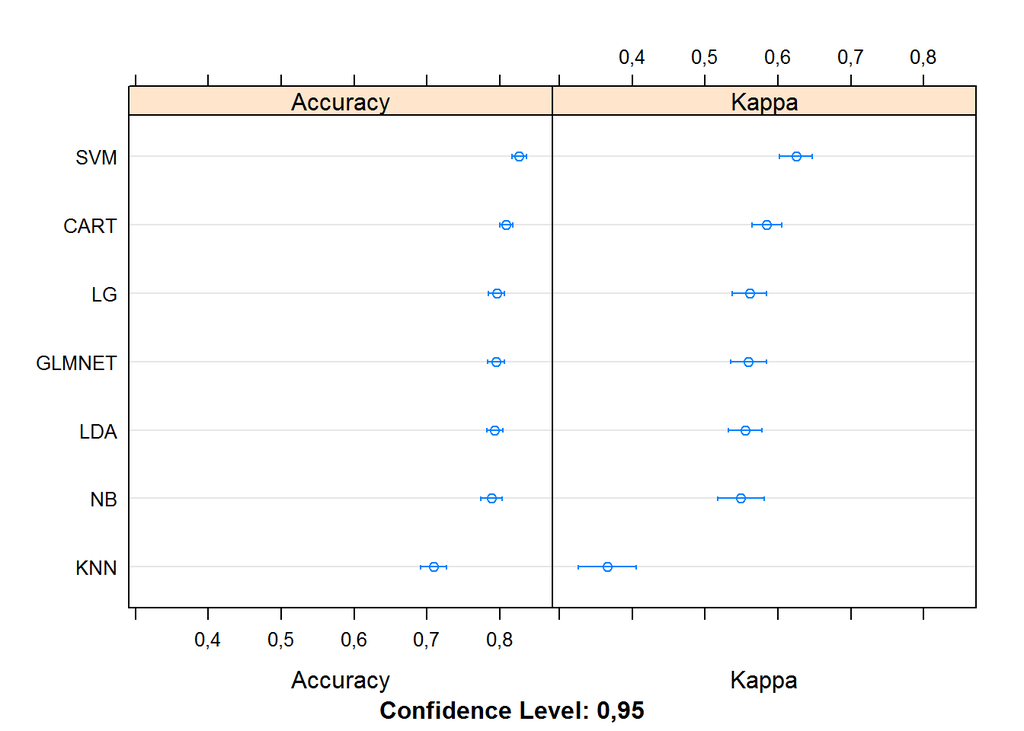

```r
dotplot(results)
```

SVM tiene la mayor precisión con un 82%.

### 4.4.5 Evaluación de los Algoritmos

Aplicaríamos una transformación Box-Cox para aplanar la distribución.

```r
# Comparar algorithms
# 10-fold validación cruzada con 3 repeticiones
trainControl <- trainControl(method="repeatedcv", number=10, repeats=3)
metric <- "Accuracy"
# LG
set.seed(7)
fit.glm <- train(Survived~., data=datasetTrain, method="glm", metric=metric, preProc=c("BoxCox"),
    trControl=trainControl)
# LDA
set.seed(7)
fit.lda <- train(Survived~., data=datasetTrain, method="lda", metric=metric, preProc=c("BoxCox"),
    trControl=trainControl)
# GLMNET
set.seed(7)
fit.glmnet <- train(Survived~., data=datasetTrain, method="glmnet", metric=metric,
    preProc=c("BoxCox"), trControl=trainControl)
# KNN
set.seed(7)
fit.knn <- train(Survived~., data=datasetTrain, method="knn", metric=metric, preProc=c("BoxCox"),
    trControl=trainControl)
# CART
set.seed(7)
fit.cart <- train(Survived~., data=datasetTrain, method="rpart", metric=metric,
    preProc=c("BoxCox"), trControl=trainControl)
# Naive Bayes
set.seed(7)
fit.nb <- train(Survived~., data=datasetTrain, method="nb", metric=metric, preProc=c("BoxCox"),
    trControl=trainControl)
# SVM
set.seed(7)
fit.svm <- train(Survived~., data=datasetTrain, method="svmRadial", metric=metric,
    preProc=c("BoxCox"), trControl=trainControl)
# Compare algorithms
transformResults <- resamples(list(LG=fit.glm, LDA=fit.lda, GLMNET=fit.glmnet, KNN=fit.knn,
    CART=fit.cart, NB=fit.nb, SVM=fit.svm))
summary(transformResults)
```

```
FALSE
FALSE Call:
FALSE summary.resamples(object = transformResults)
FALSE
FALSE Models: LG, LDA, GLMNET, KNN, CART, NB, SVM
FALSE Number of resamples: 30
FALSE
FALSE Accuracy
FALSE             Min.   1st Qu.    Median      Mean   3rd Qu.      Max. NA's
FALSE LG     0,7303371 0,7752809 0,8000000 0,7991803 0,8202247 0,8522727    0
FALSE LDA    0,7303371 0,7759051 0,7977528 0,7935201 0,8174157 0,8426966    0
FALSE GLMNET 0,7303371 0,7752809 0,7988764 0,7984354 0,8202247 0,8522727    0
FALSE KNN    0,5955056 0,6862672 0,7135101 0,7104717 0,7408389 0,7865169    0
FALSE CART   0,7528090 0,7888889 0,8089888 0,8088682 0,8277146 0,8539326    0
FALSE NB     0,7191011 0,7647004 0,7865169 0,7894717 0,8158836 0,8636364    0
FALSE SVM    0,7777778 0,8073608 0,8212235 0,8268336 0,8539326 0,8750000    0
FALSE
FALSE Kappa
FALSE              Min.   1st Qu.    Median      Mean   3rd Qu.      Max. NA's
FALSE LG     0,40896514 0,5090818 0,5685423 0,5668677 0,6213415 0,6867470    0
FALSE LDA    0,41575492 0,5154834 0,5592700 0,5552906 0,6024021 0,6489613    0
FALSE GLMNET 0,40896514 0,5090818 0,5685423 0,5652397 0,6213415 0,6867470    0
FALSE KNN    0,09235127 0,3334055 0,3748888 0,3712056 0,4341947 0,5553510    0
FALSE CART   0,45184770 0,5452032 0,5880622 0,5848022 0,6263296 0,6817056    0
FALSE NB     0,40840202 0,4963614 0,5495991 0,5500548 0,6083261 0,7060134    0
FALSE SVM    0,52254642 0,5818325 0,6184871 0,6253285 0,6770328 0,7320044    0
```

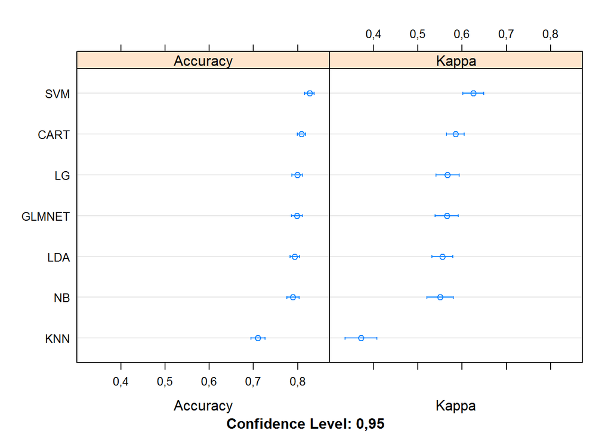

```r
dotplot(transformResults)
```

La precisión de SVM aumentó ligeramente al 83%. Aún no es lo suficientemente bueno.

## 4.5 Mejorar la precisión

Vamos ahora a probar un poco de ajuste de los mejores algoritmos, específicamente SVM y veamos si podemos aumentar la precisión.

### 4.5.1 Afinación del algoritmo

La implementación SVM tiene dos parámetros que podemos sintonizar con el paquete caret. El sigma, que es un término de suavizado, y C, que es una restricción de costos.

```r
# 10-fold validación cruzada con 3 repeticiones
trainControl <- trainControl(method="repeatedcv", number=10, repeats=3)
metric <- "Accuracy"
set.seed(7)
grid <- expand.grid(.sigma=c(0.025, 0.05, 0.1, 0.15), .C=seq(1, 10, by=1))
fit.svm <- train(Survived~., data=datasetTrain, method="svmRadial", metric=metric, tuneGrid=grid,
    preProc=c("BoxCox"), trControl=trainControl)
print(fit.svm)
```

```
FALSE Support Vector Machines with Radial Basis Function Kernel
FALSE
FALSE 891 samples
FALSE   6 predictor
FALSE   2 classes: '0', '1'
FALSE
FALSE Pre-processing: Box-Cox transformation (1)
FALSE Resampling: Cross-Validated (10 fold, repeated 3 times)
FALSE Summary of sample sizes: 802, 801, 802, 802, 802, 801, ...
FALSE Resampling results across tuning parameters:
FALSE
FALSE   sigma  C   Accuracy   Kappa
FALSE   0,025   1  0,8010067  0,5686501
FALSE   0,025   2  0,8069953  0,5814050
FALSE   0,025   3  0,8133754  0,5947552
FALSE   0,025   4  0,8144949  0,5974154
FALSE   0,025   5  0,8174912  0,6043062
FALSE   0,025   6  0,8193682  0,6083989
FALSE   0,025   7  0,8193640  0,6084256
FALSE   0,025   8  0,8208621  0,6117278
FALSE   0,025   9  0,8201130  0,6101441
FALSE   0,025  10  0,8219732  0,6140058
FALSE   0,050   1  0,8148568  0,5979645
FALSE   0,050   2  0,8204708  0,6109339
FALSE   0,050   3  0,8242120  0,6191978
FALSE   0,050   4  0,8264425  0,6235115
FALSE   0,050   5  0,8264425  0,6237200
FALSE   0,050   6  0,8257019  0,6219443
FALSE   0,050   7  0,8249611  0,6204388
FALSE   0,050   8  0,8249653  0,6206149
FALSE   0,050   9  0,8249610  0,6204715
FALSE   0,050  10  0,8253356  0,6213865
FALSE   0,100   1  0,8241995  0,6192417
FALSE   0,100   2  0,8238289  0,6177977
FALSE   0,100   3  0,8234586  0,6169659
FALSE   0,100   4  0,8230840  0,6161147
FALSE   0,100   5  0,8227094  0,6153527
FALSE   0,100   6  0,8230882  0,6162456
FALSE   0,100   7  0,8234543  0,6168225
FALSE   0,100   8  0,8245737  0,6192898
FALSE   0,100   9  0,8256973  0,6220048
FALSE   0,100  10  0,8271913  0,6252692
FALSE   0,150   1  0,8249526  0,6205838
FALSE   0,150   2  0,8242035  0,6186198
FALSE   0,150   3  0,8238288  0,6181439
FALSE   0,150   4  0,8264337  0,6238168
FALSE   0,150   5  0,8268041  0,6243004
FALSE   0,150   6  0,8253184  0,6218912
FALSE   0,150   7  0,8245695  0,6204264
FALSE   0,150   8  0,8230755  0,6176496
FALSE   0,150   9  0,8227052  0,6172628
FALSE   0,150  10  0,8204622  0,6126868
FALSE
FALSE Accuracy was used to select the optimal model using the largest value.
FALSE The final values used for the model were sigma = 0,1 and C = 10.
```

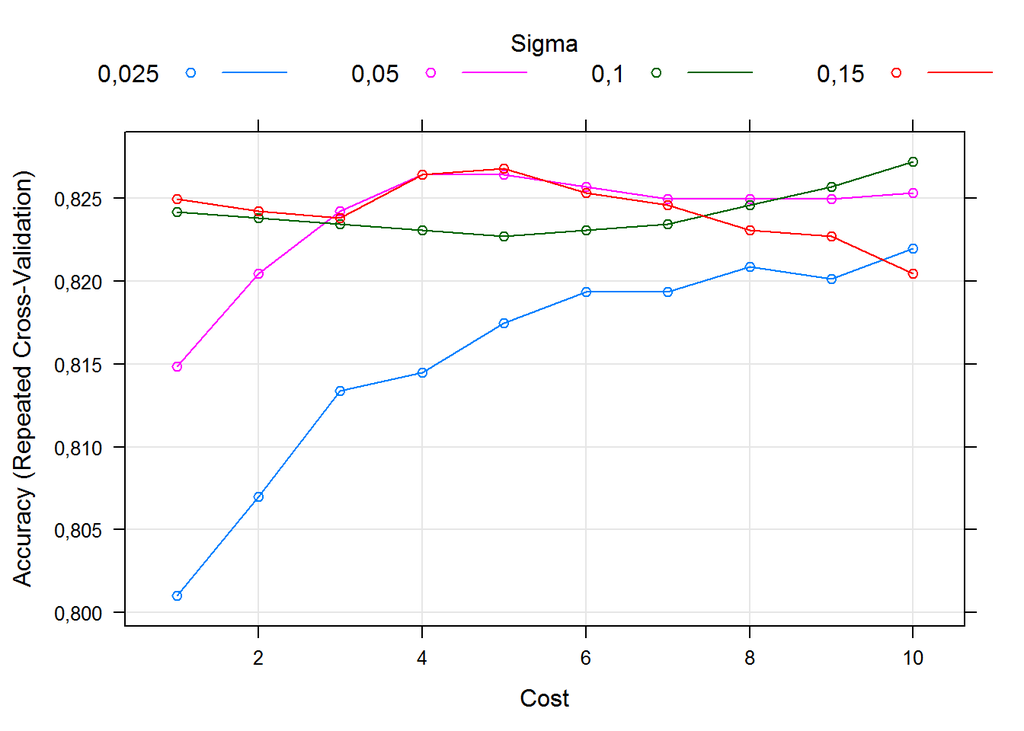

```r
plot(fit.svm)
```

### 4.5.2 Conjuntos

- **Bagging**: contenedor CART (BAG) y random forest (RF).
- **Boosting**: aumento de gradiente estocástico (GBM) y C5.0 (C50).

```r
# 10-fold validación cruzada con 3 repeticiones
trainControl <- trainControl(method="repeatedcv", number=10, repeats=3)
metric <- "Accuracy"

# Bagged CART
set.seed(7)
fit.treebag <- train(Survived~., data=datasetTrain, method="treebag", metric=metric,
    trControl=trainControl)

# Random Forest
set.seed(7)
fit.rf <- train(Survived~., data=datasetTrain, method="rf", metric=metric, preProc=c("BoxCox"),
    trControl=trainControl)

# Stochastic Gradient Boosting
set.seed(7)
fit.gbm <- train(Survived~., data=datasetTrain, method="gbm", metric=metric, preProc=c("BoxCox"),
    trControl=trainControl, verbose=FALSE)

# C5.0
#set.seed(7)
#fit.c50 <- train(Survived~., data=datasetTrain, method="C5.0", metric=metric, preProc=c("BoxCox"),
#    trControl=trainControl)

# Compare results
#ensembleResults <- resamples(list(BAG=fit.treebag, RF=fit.rf, GBM=fit.gbm, C50=fit.c50))
ensembleResults <- resamples(list(BAG=fit.treebag, RF=fit.rf, GBM=fit.gbm))
summary(ensembleResults)
```

```
FALSE
FALSE Call:
FALSE summary.resamples(object = ensembleResults)
FALSE
FALSE Models: BAG, RF, GBM
FALSE Number of resamples: 30
FALSE
FALSE Accuracy
FALSE          Min.   1st Qu.    Median      Mean   3rd Qu.      Max. NA's
FALSE BAG 0,7333333 0,7780899 0,7966037 0,7968699 0,8105805 0,9000000    0
FALSE RF  0,7777778 0,8089888 0,8314607 0,8283023 0,8426966 0,9111111    0
FALSE GBM 0,7865169 0,8089888 0,8202247 0,8279533 0,8426966 0,9000000    0
FALSE
FALSE Kappa
FALSE          Min.   1st Qu.    Median      Mean   3rd Qu.      Max. NA's
FALSE BAG 0,4503817 0,5293626 0,5644184 0,5652154 0,5911308 0,7862797    0
FALSE RF  0,5121951 0,5797123 0,6326882 0,6274213 0,6565691 0,8110236    0
FALSE GBM 0,5340599 0,5789828 0,6206493 0,6284172 0,6611033 0,7885117    0
```

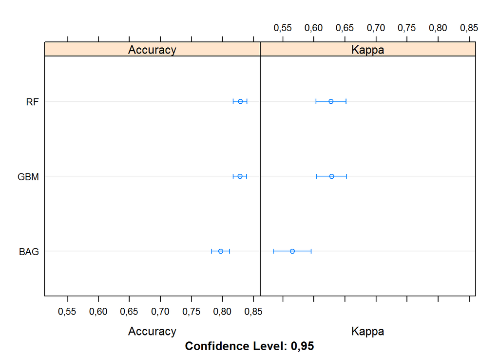

```r
dotplot(ensembleResults)
```

### 4.5.3 Finalizar el modelo

Vamos a finalizar el modelo de SVM para usar en todo nuestro conjunto de entrenamiento.

```r
# preparar parámetros para la transformación de datos
# set.seed(7)
model <- svm(Survived ~ ., data = datasetTrain)

# se eliminan variables redundantes
datasetTrain <- titanic_test[,c(-3, -8, -10, -11, -c(12:23))]

# Se ajustan los datos como en el conjunto de entrenamiennto
datasetTest <- titanic_test
testData <- datasetTest[,c(-1, -4, -9, -11, -12)]

testData$Pclass = as.integer(testData$Pclass)
testData$Age = as.integer(testData$Age)
testData$Sex <- as.numeric(testData$Sex)
testData$Survived <- as.factor(testData$Survived)

preprocessParams <- preProcess(testData, method=c("BoxCox"))
testData$Age[is.na(testData$Age)] <- 0
testData$Fare[is.na(testData$Fare)] <- 0
testData <- predict(preprocessParams, testData)

predictions <- predict(model, testData, type="class")
submit <- data.frame(PassengerId = datasetTest$PassengerId, Survived = predictions)

# ajustamos la salidad de los resultados
csv_dir = paste(baseDirectory, "/", "resultados", sep="")
setwd(csv_dir)
write.csv(submit, file = "firstSVM.csv", row.names = FALSE)
# retornamos al directorio para trabajar con el shp
setwd(baseDirectory)
```

# 5 Representación de los resultados a partir de tablas y gráficas

Datos del test:

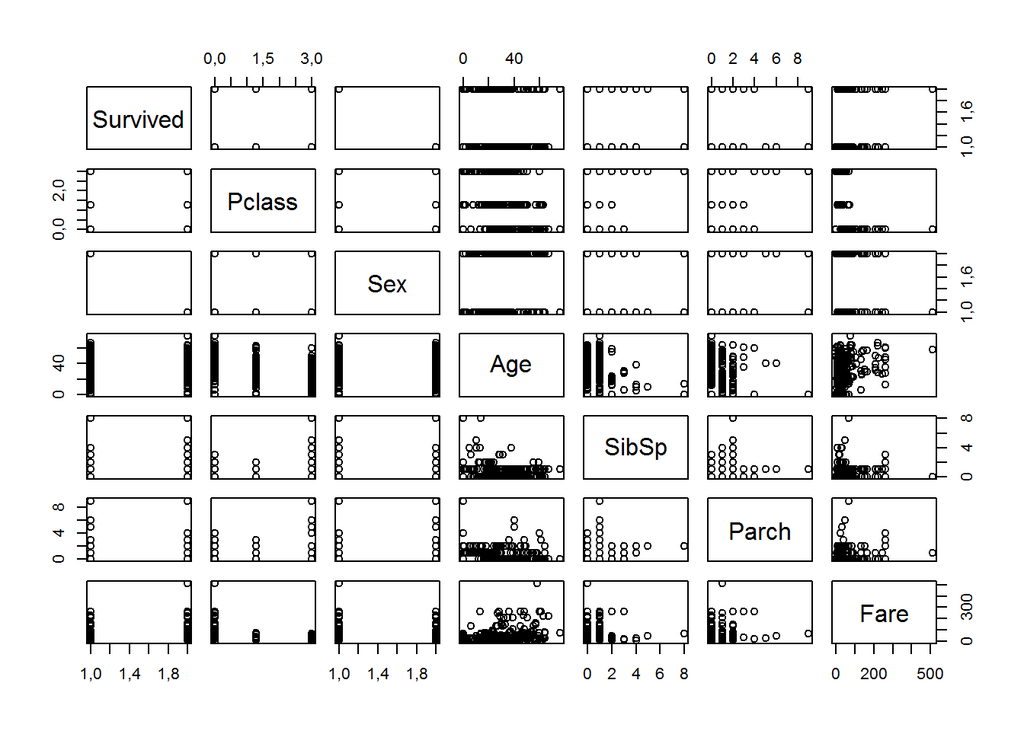

```r
plot(testData)
```

```r
#plot(predictions)
```

```r
predictedTest_mg = merge(x = submit, y = datasetTest,by.x="PassengerId", by.y =  "PassengerId")
predicted_names = names(predictedTest_mg)
predicted_names[2]="Surv. Predicted"
predicted_names[3]="Surv. Original"
names(predictedTest_mg) = predicted_names

wrongSurvivedPred = predictedTest_mg[predictedTest_mg$`Surv. Predicted`!=predictedTest_mg$`Surv. Original`,]
successSurvivedPred = predictedTest_mg[predictedTest_mg$`Surv. Predicted`==predictedTest_mg$`Surv. Original`,]

datatable(wrongSurvivedPred)
```

|  | PassengerId | Surv. Predicted | Surv. Original | Pclass | Name | Sex | Age | SibSp | Parch | Ticket | Fare | Cabin | Embarked |
| --- | --- | --- | --- | --- | --- | --- | --- | --- | --- | --- | --- | --- | --- |
| 22 | 913 | 1 | 0 | 3 | Olsen, Master. Artur Karl | male | 9 | 0 | 1 | C 17368 | 3.1708 |  | S |
| 33 | 924 | 0 | 1 | 3 | Dean, Mrs. Bertram (Eva Georgetta Light) | female | 33 | 1 | 2 | C.A. 2315 | 20.575 |  | S |
| 70 | 961 | 0 | 1 | 1 | Fortune, Mrs. Mark (Mary McDougald) | female | 60 | 1 | 4 | 19950 | 263 | C23 C25 C27 | S |
| 81 | 972 | 1 | 0 | 3 | Boulos, Master. Akar | male | 6 | 1 | 1 | 2678 | 15.2458 |  | C |
| 90 | 981 | 1 | 0 | 2 | Wells, Master. Ralph Lester | male | 2 | 1 | 1 | 29103 | 23 |  | S |
| 133 | 1024 | 0 | 1 | 3 | Lefebre, Mrs. Frank (Frances) | female |  | 0 | 4 | 4133 | 25.4667 |  | S |
| 141 | 1032 | 0 | 1 | 3 | Goodwin, Miss. Jessie Allis | female | 10 | 5 | 2 | CA 2144 | 46.9 |  | S |
| 162 | 1053 | 1 | 0 | 3 | Touma, Master. Georges Youssef | male | 7 | 1 | 1 | 2650 | 15.2458 |  | C |
| 189 | 1080 | 0 | 1 | 3 | Sage, Miss. Ada | female |  | 8 | 2 | CA. 2343 | 69.55 |  | S |
| 193 | 1084 | 1 | 0 | 3 | van Billiard, Master. Walter John | male | 11.5 | 1 | 1 | A/5. 851 | 14.5 |  | S |

[output cut: 11 more lines]

La anterior es una tabla con los resultados que no se aciertan con los esperados del conjunto de test.

```r
length(wrongSurvivedPred$`Surv. Predicted`)/length(predictedTest_mg$`Surv. Predicted`)
```

```
## [1] 0,05023923
```

```r
success = length(successSurvivedPred$`Surv. Predicted`)/length(predictedTest_mg$`Surv. Predicted`)
fail = length(wrongSurvivedPred$`Surv. Predicted`)/length(predictedTest_mg$`Surv. Predicted`)

df.pred.results = data.frame(success = success, fail = fail)
```

Se muestran los porcentajes de acierto sobre los resultados esperados:

Porcentajes de resultados de acierto en la predicción con SVM

| success | fail |
| --- | --- |
| 0,95 | 0,05 |

Como se puede ver, el acierto esta por encima del 94%, aunque siempre es posible mejorarlo.

Ahora mostramos una distribución de las prediciones finales:

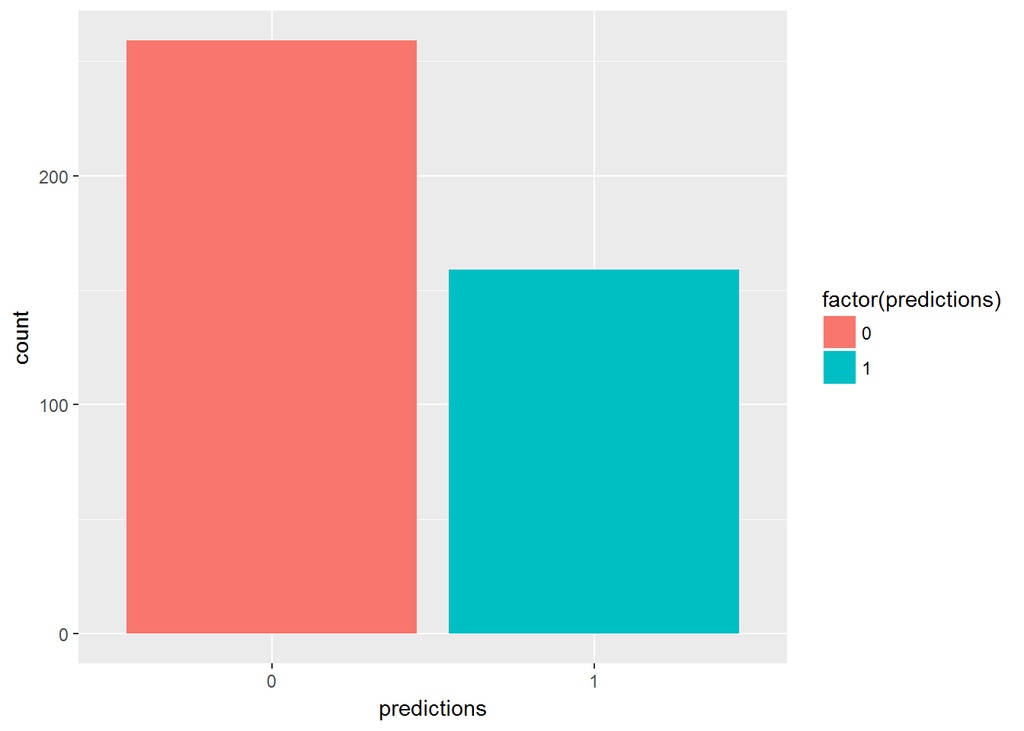

```r
ggplot(as.data.frame(as.integer(predictions)) , aes(x = predictions, fill = factor(predictions))) +
  geom_bar(stat='count', position='dodge')
```

# 6 Resolución del problema

Los resultados permiten responder los planteamientos inciales del problema, a saber, que con los datos aportados por el dataset se pueden extraer conclusiones sobre la posibilidad de supervivencia de los pasajeros en función de las variables aportadas.

Como se ha podido comprobar, no se ha utilizado una selección a priori de las variables a utilizar para abordar la resolución del problema, ya que se ha considerado más prudente observar el comportamiento de las variables, su ajuste en el proceso de limpieza y análisis, y el posterior comportamiento en las métricas de resultados segun se han ido realizando pruebas con los distintos modelos.

# 7 Código en R

Este modelo de resolución de supervivencia del titanic se encuentra en el repositorio GitHub, en la localización: https://github.com/rgarciarui/titanicDataClean